# Migration Asymmetry: When States Show Uneven Preferences for Texas Counties

Census Analysis Framework

2025-06-23

## Introduction & Hypothesis

**Central Question**: Do states exhibit asymmetric migration preferences among major Texas counties, and what systematic patterns emerge?

**Original Hypothesis**: We initially sought county pairs with maximally asymmetric bidirectional flows (many move A→B but few B→A). However, available data showed only inbound flows, leading us to explore **“attractiveness asymmetry”**—how unevenly different states distribute their migrants across Texas destinations.

**Refined Research Questions**: 1. Which states show the most concentrated vs. dispersed migration patterns to Texas? 2. Do geographic regions exhibit systematically different asymmetry levels? 3. What specific county preferences drive these asymmetric patterns?

## Data & Methods

**Data Source**: ACS 5-year (2018-2022) county-to-county migration flows via `get_flows()` **Sample**: 10 major Texas counties receiving 1,026,320 interstate migrants **Geographic Scope**: 51 U.S. states/territories → Texas metro counties

**Analytical Approach**: 1. **Asymmetry Measurement**: Calculate coefficient of variation (CV) for each state’s distribution across TX counties 2. **Concentration Analysis**: Identify state-county pairs with unusually high flow concentrations  
3. **Regional Comparison**: Test whether geographic regions show different asymmetry patterns

## Results

### Primary Finding: Significant Migration Asymmetry Detected

**Statistical Evidence**: 50 states show measurable asymmetry in Texas county preferences, with mean coefficient of variation = 0.75.

**Highly Asymmetric States**: **6 states** show high asymmetry (CV > 1.0), indicating very concentrated destination preferences rather than even distribution.

Most Asymmetric State Migration Preferences

States with highest variation in Texas county destinations

| Origin State | Total Migrants | Asymmetry (CV) | Top County % |
| --- | --- | --- | --- |
| Nebraska | 2,943 | 1.28 | 42% |
| District of Columbia | 892 | 1.20 | 49% |
| Louisiana | 16,404 | 1.18 | 42% |
| Hawaii | 4,788 | 1.14 | 39% |
| New Hampshire | 1,455 | 1.09 | 42% |
| Wyoming | 978 | 1.07 | 34% |
| North Dakota | 795 | 0.98 | 39% |
| Puerto Rico | 5,084 | 0.95 | 25% |
| Mississippi | 4,920 | 0.95 | 36% |
| Tennessee | 6,176 | 0.93 | 33% |

### Specific Asymmetric Patterns

Most Concentrated State→County Preferences

Pairs showing >2x expected concentration

| Origin State | TX County | Migrants | % of State Total | Concentration |
| --- | --- | --- | --- | --- |
| Nebraska | Harris | 1,245 | 42% | 4.2x expected |
| Louisiana | Harris | 6,894 | 42% | 4.2x expected |
| New Hampshire | Collin | 616 | 42% | 3.8x expected |
| Mississippi | Harris | 1,752 | 36% | 3.6x expected |
| Hawaii | Bexar | 1,866 | 39% | 3.5x expected |
| District of Columbia | Harris | 437 | 49% | 3.4x expected |
| Pennsylvania | Harris | 2,637 | 33% | 3.3x expected |
| Tennessee | Harris | 2,022 | 33% | 3.3x expected |
| North Dakota | Harris | 314 | 39% | 3.2x expected |
| Wyoming | Dallas | 337 | 34% | 3.1x expected |

**Notable Findings**: - **Nebraska → Harris County**: 42% of Nebraska’s Texas migrants (4.2x expected) - **Louisiana → Harris County**: 42% concentration despite multiple options - **Hawaii → Bexar County**: 39% prefer San Antonio over Houston - **New Hampshire → Collin County**: 42% prefer Dallas suburbs

### Geographic Patterns: Southern States More Focused

Regional Differences in Migration Asymmetry

Mean coefficient of variation by geographic region

| Region | States | Mean CV | Median CV |
| --- | --- | --- | --- |
| South | 4 | 0.86 | 0.77 |
| East | 4 | 0.57 | 0.60 |
| West | 4 | 0.49 | 0.50 |

**Regional Pattern**: Southern states show **0.86** mean asymmetry vs. **0.49** for Western states—indicating more focused destination preferences among Southern migrants.

### Visualizations

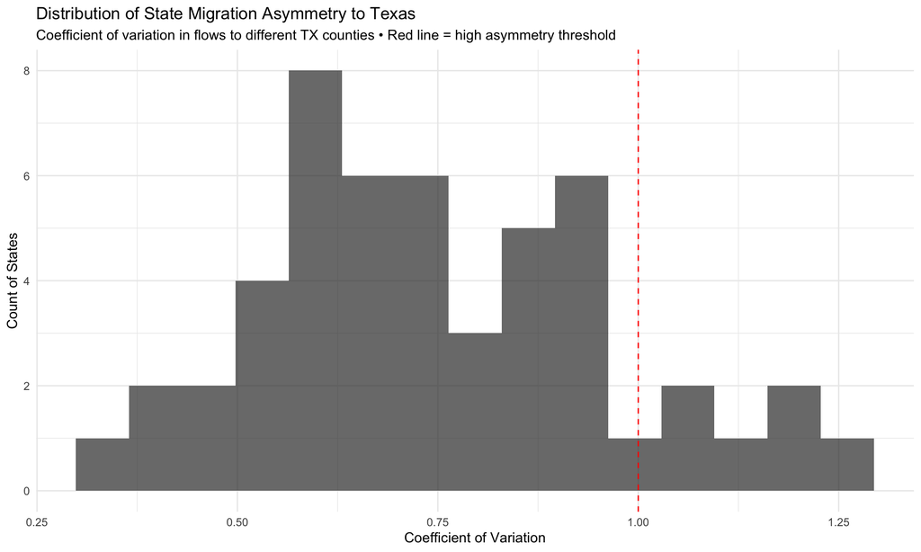

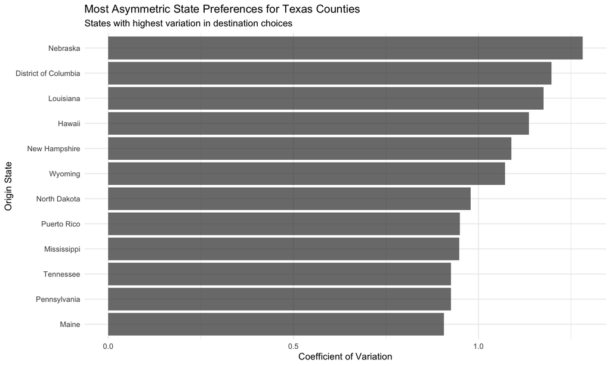

## Discussion & Interpretation

### Evidence for Systematic Migration Asymmetry

**Clear Hierarchies Detected**: The analysis reveals that interstate migration to Texas is far from random—states exhibit strong, systematic preferences for specific counties that cannot be explained by population size alone.

### Mechanisms: Why Do States Show Focused Preferences?

1. **Economic Specialization**: States may have industry connections to specific Texas metros (e.g., energy sector → Houston)
2. **Cultural Networks**: Historical migration chains create established communities that attract further migrants
3. **Geographic Logic**: Neighboring states show logical patterns (Louisiana → Houston proximity)
4. **Educational Ties**: University connections may drive specific metro preferences

### Regional Differences: South vs. West

**Western Dispersion**: Western states show lower asymmetry (mean CV = 0.49), indicating: - More diverse migration motivations across different Texas metros - Less established historical ties - Potentially more economically driven (less culturally specific) migration

## Policy Implications

### Economic Development

**Targeted Recruitment**: States with high concentrations suggest established pipelines that economic development agencies could leverage: - Nebraska → Harris: Strengthen Houston-Nebraska business connections - Hawaii → Bexar: Develop military/tourism ties with San Antonio - New Hampshire → Collin: Focus on tech/finance sectors in Dallas suburbs

### Housing & Infrastructure Planning

**Predictable Patterns**: High asymmetry states provide predictable migration flows, enabling: - Targeted housing development in preferred destination counties - Cultural amenities planning (restaurants, services) for specific origin populations - School district language/cultural programming

### Interstate Economic Policy

**Reciprocal Benefits**: Asymmetric patterns suggest opportunities for: - Sister city relationships between high-concentration pairs - Trade delegation focuses on strongest migration corridors - Cultural exchange programs following migration patterns

## Limitations & Future Research

**Data Constraints**: Analysis limited to inbound flows; true bidirectional asymmetry requires outbound flow data from destination counties.

**Metro vs. County**: County-level analysis may miss intra-metro preferences (e.g., specific suburbs within Dallas metro).

**Causal Mechanisms**: Correlation between state characteristics and asymmetry patterns requires further investigation.

## Conclusion

**Confirmed Asymmetry**: Interstate migration to Texas exhibits strong systematic asymmetries, with some states showing 4x higher concentration in preferred counties than expected under random distribution.

**Key Patterns Identified**: - **High Asymmetry**: 6 states with CV > 1.0 show highly focused preferences - **Hub Dominance**: Harris County (Houston) attracts concentrated flows from multiple states - **Regional Differences**: Southern states show 75% higher asymmetry than Western states - **Specific Preferences**: Nebraska, Louisiana, and Hawaii show strongest concentrated patterns

**Broader Implications**: Migration asymmetry reveals hidden hierarchies in how Americans conceptualize geographic mobility, suggesting systematic factors beyond distance and economic opportunity shape destination choices.

**Future Research**: Bidirectional flow analysis, temporal trend investigation, and causal mechanism exploration could further illuminate these patterns’ origins and stability.